# Follow-up on Meeting from 20 August, 2024

### Ordered by decreasing log fold-change (i.e. up-regulated)

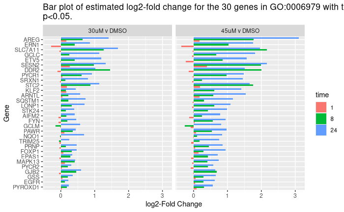

```r
de.barplot(30, erad.genes, order_by = 'up', title = function(n, order_by) {paste(
  "Bar plot of estimated log2-fold change for the",
  n,
  "genes in GO:0006979 with the greatest log fold-change with p<0.05."
)})
```

### Ordered by increasing log fold-change (i.e. down-regulated)

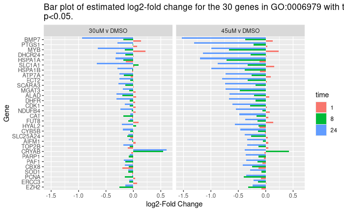

```r
de.barplot(30, erad.genes, order_by = 'down', title = function(n, order_by) {paste(
  "Bar plot of estimated log2-fold change for the",
  n,
  "genes in GO:0006979 with the least log fold-change with p<0.05."
)})
```

### Ordered by decreasing absolute log fold-change (i.e. effect far from zero)

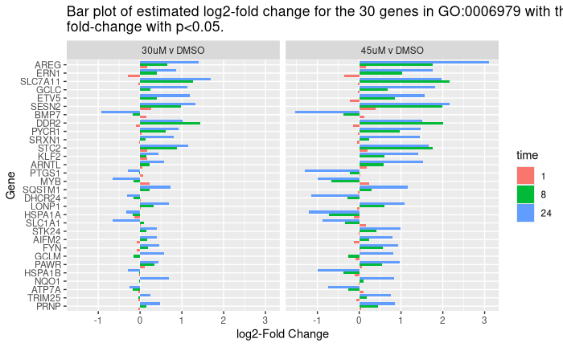

```r
de.barplot(30, erad.genes, order_by = 'any', title = function(n, order_by) {paste(
  "Bar plot of estimated log2-fold change for the",
  n,
  "genes in GO:0006979 with the greatest absolute log fold-change with p<0.05."
)})
```

# Mitochondrial Fusion genes

## Ordered by increasing $p$

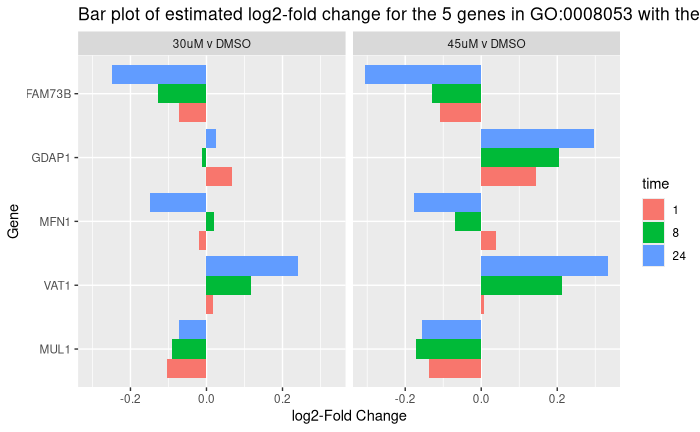

```r
erad.genes <- (as.data.frame(org.Hs.egALIAS2EG) %>%
  filter(gene_id %in% as.data.frame(org.Hs.egGO2ALLEGS["GO:0008053"])$gene_id) %>%
  filter(alias_symbol %in% rownames(results(dds))) %>%
  filter(alias_symbol %in% df.raw$gene))$alias_symbol

de.barplot(5, genes=erad.genes, title = function(n, order_by) {paste(
  "Bar plot of estimated log2-fold change for the",
  n,
  "genes in GO:0008053 with the lowest p-value."
)})
```

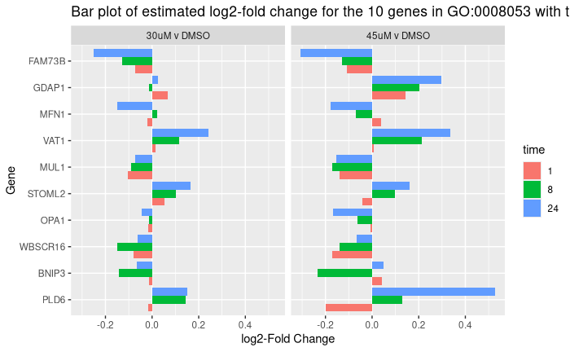

```r
de.barplot(10, genes=erad.genes, title = function(n, order_by) {paste(
  "Bar plot of estimated log2-fold change for the",
  n,
  "genes in GO:0008053 with the lowest p-value."
)})
```

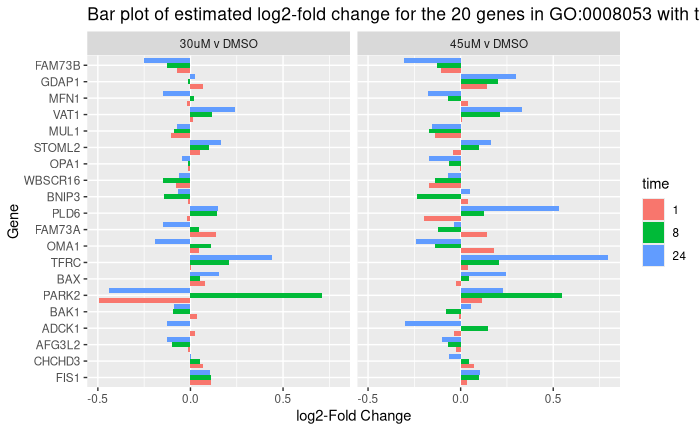

```r
de.barplot(20, erad.genes, title = function(n, order_by) {paste(
  "Bar plot of estimated log2-fold change for the",
  n,
  "genes in GO:0008053 with the lowest p-value."
)})
```

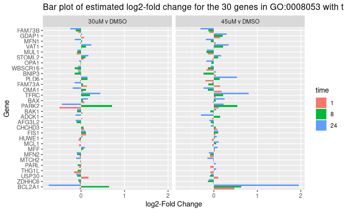

```r
de.barplot(30, erad.genes, title = function(n, order_by) {paste(
  "Bar plot of estimated log2-fold change for the",
  n,
  "genes in GO:0008053 with the lowest p-value."
)})
```

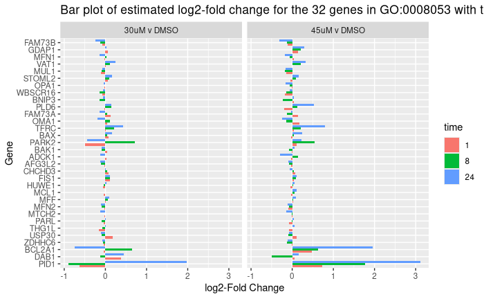

```r
de.barplot(32, erad.genes, title = function(n, order_by) {paste(
  "Bar plot of estimated log2-fold change for the",
  n,
  "genes in GO:0008053 with the lowest p-value."
)})
```

> None had $p < 0.05$, so can’t make the other plots

# Misc gene sets

> Found a bug in my previous code that removed ~6000 genes with $p\approx 1$ from the analysis. I also changed the type-I error rate to 0.05. GSEA results are slightly different as a result.

Below is a waterfall plot of the Allez-significant gene sets. It shows, first, the gene-set that contains the most genes with adjusted $p < 0.05$, and plots that number of genes. Then it, iteratively, selects the next best such set, but considering only those genes not contained in the previously selected sets.

```r
allez.dat <- as.numeric(!is.na(results(dds)$padj) & (results(dds)$padj < 0.05))
names(allez.dat) <- rownames(dds)
allez.out <- allez(allez.dat, "org.Hs.eg", idtype = "SYMBOL")
```

```
Loading necessary libraries...
Loaded Package org.Hs.eg.db
Converting annotations to data.frames ...
Labeling output ...
Loaded Package GO.db
```

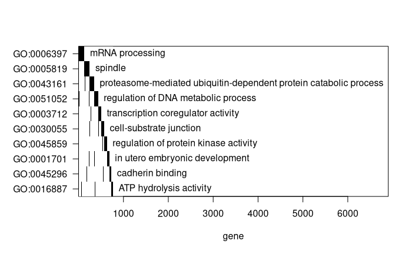

```r
allezPlot(allez.out)
```

```r
#allezTable(allez.out)
```

## pathfindR

I found this nifty tool that performs simultaneous network/gene set enrichment analysis in KEGG pathways. I have not yet been able to look into the mathematics of what it does, so I can’t speak to the meaningfulness of these results. But it provides some nice visualization tools.

```
## Testing input
The input looks OK
## Processing input. Converting gene symbols,
          if necessary (and if human gene symbols provided)
Number of genes provided in input: 19084
Number of genes in input after p-value filtering: 2449
pathfindR cannot handle p values < 1e-13. These were changed to 1e-13
Could not find any interactions for 15 (0.61%) genes in the PIN
Final number of genes in input: 2434
## Performing Active Subnetwork Search and Enrichment
`n_processes` is set to `iterations` because `iterations` < `n_processes`
## Processing the enrichment results over all iterations
## Annotating involved genes and visualizing enriched terms
Plotting the enrichment bubble chart
```

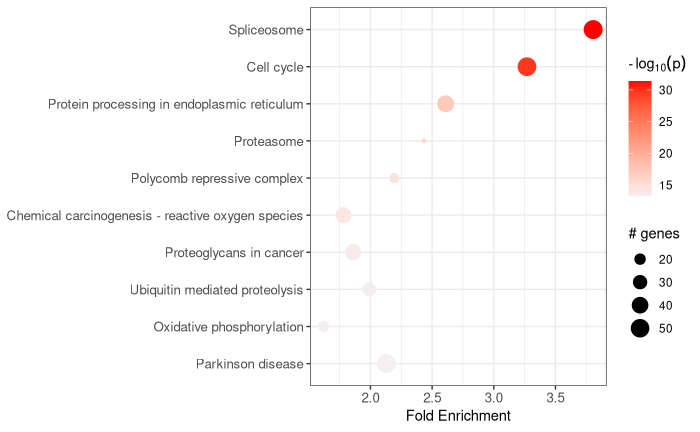

```r
path.out <- run_pathfindR(
  as.data.frame(results(dds)) %>%
    mutate(gene = rownames(.)) %>%
    dplyr::select(gene, log2FoldChange, padj) %>%
    mutate(padj = ifelse(is.na(padj), 1, padj))
)
```

See the term_visualizations folder for a real treat. Those show the KEGG pathways, with DE genes highlighted green (up-regulated) or red (down-regulated). As I mentioned earlier, I don’t yet know the math behind how it got these values, so not publication ready yet, as far as I’m concerned. But they at least provide a nice visualization to help elucidate what should be further explored.

You can also see the kegg_pathways.csv file for information on each pathway.

A hierarchical clustering of the top-10 KEGG pathways is displayed below.

```
The maximum average silhouette width was 0.11 for k = 4
```

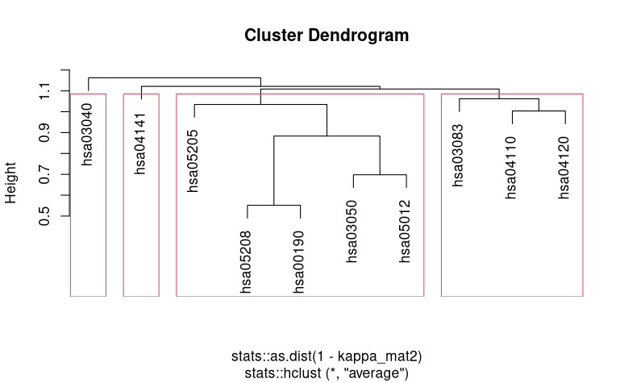

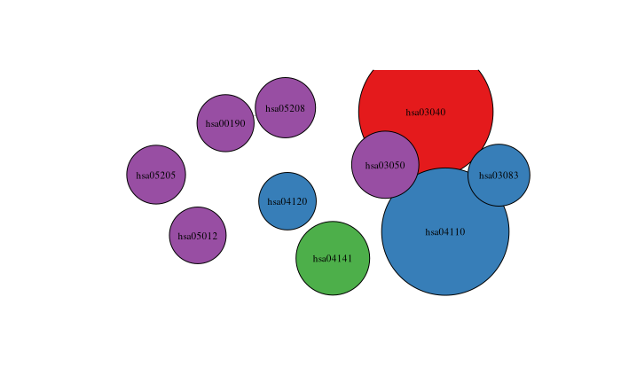

```r
clu <- cluster_enriched_terms(path.out[1:10,], use_description = F, method="hierarchical")
```

The plot below shows a plot of the genes of the top 3 terms, along with teh direction of change. As you can see, these three terms share very few genes in common.

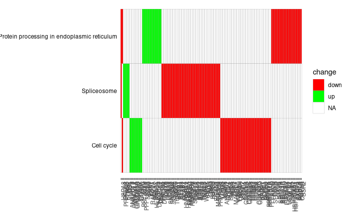

```r
term_gene_heatmap(path.out, num_terms = 3, use_description = T)
```

And here is an attempt to plot a graph of the top pathways. It is very hard to interpret. I may be able to make it more legible, if this is of interest.

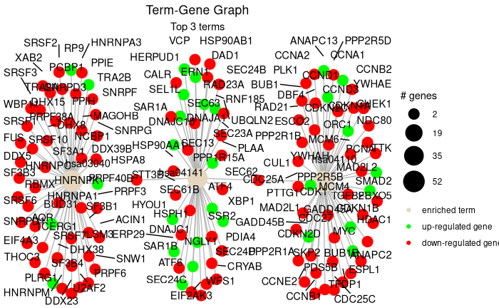

```r
term_gene_graph(path.out, num_terms = 3)
```

# Comparison Comparisons

```r
contrasts <- list(
  h24_45vD = c(
    0, # Intercept
    0, # IC50
    1, # IC75
    0, # Time 8
    0, # Time 24
    0, # Batch b
    0, # Batch c
    0, # IC50 x Time 8
    0, # IC75 x Time 8
    0, # IC50 x Time 24
    1  # IC75 x Time 24
  ),
  h24_30vD = c(
    0, # Intercept
    1, # IC50
    0, # IC75
    0, # Time 8
    0, # Time 24
    0, # Batch b
    0, # Batch c
    0, # IC50 x Time 8
    0, # IC75 x Time 8
    1, # IC50 x Time 24
    0  # IC75 x Time 24
  ),
  h8_45vD = c(
    0, # Intercept
    0, # IC50
    1, # IC75
    0, # Time 8
    0, # Time 24
    0, # Batch b
    0, # Batch c
    0, # IC50 x Time 8
    1, # IC75 x Time 8
    0, # IC50 x Time 24
    0  # IC75 x Time 24
  ),
  h8_30vD = c(
    0, # Intercept
    1, # IC50
    0, # IC75
    0, # Time 8
    0, # Time 24
    0, # Batch b
    0, # Batch c
    1, # IC50 x Time 8
    0, # IC75 x Time 8
    0, # IC50 x Time 24
    0  # IC75 x Time 24
  )
)
```

| c1 | c2 | n | time1 | time2 | d11 | d12 | d21 | d22 |
| --- | --- | --- | --- | --- | --- | --- | --- | --- |
| h24_45vD | h24_30vD | 101 | 24 Hours | 24 Hours | 45 uM | DMSO | 30 uM | DMSO |
| h24_45vD | h8_45vD | 153 | 24 Hours | 8 Hours | 45 uM | DMSO | 45 uM | DMSO |
| h24_45vD | h8_30vD | 12 | 24 Hours | 8 Hours | 45 uM | DMSO | 30 uM | DMSO |
| h24_30vD | h8_45vD | 68 | 24 Hours | 8 Hours | 30 uM | DMSO | 45 uM | DMSO |
| h24_30vD | h8_30vD | 12 | 24 Hours | 8 Hours | 30 uM | DMSO | 30 uM | DMSO |
| h8_45vD | h8_30vD | 12 | 8 Hours | 8 Hours | 45 uM | DMSO | 30 uM | DMSO |
| h24_30vD | h24_45vD | 101 | 24 Hours | 24 Hours | 30 uM | DMSO | 45 uM | DMSO |
| h8_45vD | h24_45vD | 153 | 8 Hours | 24 Hours | 45 uM | DMSO | 45 uM | DMSO |
| h8_30vD | h24_45vD | 12 | 8 Hours | 24 Hours | 30 uM | DMSO | 45 uM | DMSO |
| h8_45vD | h24_30vD | 68 | 8 Hours | 24 Hours | 45 uM | DMSO | 30 uM | DMSO |

[output cut: 6 more lines]

|  | h24_30vD and h24_45vD | h8_45vD and h24_45vD | h8_30vD and h24_45vD | h24_45vD and h24_30vD | h8_45vD and h24_30vD | h8_30vD and h24_30vD | h24_45vD and h8_45vD | h24_30vD and h8_45vD | h8_30vD and h8_45vD | h24_45vD and h8_30vD | h24_30vD and h8_30vD | h8_45vD and h8_30vD | h24_45vD | h24_30vD and not h24_45vD | h8_45vD and not h24_45vD | h8_30vD and not h24_45vD | h24_45vD and not h24_30vD | h24_30vD | h8_45vD and not h24_30vD | h8_30vD and not h24_30vD | h24_45vD and not h8_45vD | h24_30vD and not h8_45vD | h8_45vD | h8_30vD and not h8_45vD | h24_45vD and not h8_30vD | h24_30vD and not h8_30vD | h8_45vD and not h8_30vD | h8_30vD |
| --- | --- | --- | --- | --- | --- | --- | --- | --- | --- | --- | --- | --- | --- | --- | --- | --- | --- | --- | --- | --- | --- | --- | --- | --- | --- | --- | --- | --- |
| 1 | AAGAB | AAGAB | ADM2 | AAGAB | ADM2 | AAGAB | AARS | ADM2 | RPL36A-HNRNPH2 | ADM2 | AKNA | ADM2 | COPB2 | ADM2 | AARS | AARS | ADM2 | ACSS2 | AARS | AARS | ADM2 | ADM2 |  | ADM2 |  | ADM2 |  | ADM2 |
| 2 | AARS | AARS | AKNA | AARS | CEBPB | ABCA12 | ABCD3 | AKNA |  | AKNA | ALAS1 | CEBPB | CSF1 | AKNA | ABCD3 | ABCD3 | AKNA | ATF4 | ABCD3 | ABCD3 | CEBPB | CEBPB |  | CEBPB |  | CEBPB |  | CEBPB |
| 3 | ABCA12 | ABCA12 | ALAS1 | ABCA12 | CHAC1 | ABCA2 | ADM2 | ALAS1 |  | ALAS1 | ASNS | CHAC1 | CTR9 | ALAS1 | ACSS2 | ACSS2 | ALAS1 | JDP2 | ADM2 | ACSS2 | CHAC1 | CHAC1 |  | CHAC1 |  | CHAC1 |  | CHAC1 |
| 4 | ABCA2 | ABCA2 | ASNS | ABCA2 | DDIT3 | ABCB6 | ADORA1 | ASNS |  | ASNS | CALCB | DDIT3 | DTD1 | ASNS | ADM2 | ADORA1 | ASNS | KLF15 | ADORA1 | ADORA1 | DDIT3 | DDIT3 |  | DDIT3 |  | DDIT3 |  | DDIT3 |
| 5 | ABCB6 | ABCB6 | CALCB | ABCB6 | GDF15 | ABCB7 | AKNA | CALCB |  | CALCB | CARS | GDF15 | EID2 | CALCB | ADORA1 | ALDH1L2 | CALCB | KLF9 | AKNA | AKNA | GDF15 | GDF15 |  | GDF15 |  | GDF15 |  | GDF15 |
| 6 | ABCB7 | ABCB7 | CARS | ABCB7 | KCNG1 | ABCC3 | ALAS1 | CARS |  | CARS | CBS | KCNG1 | FTH1 | CARS | AKNA | ANKRD11 | CARS | TUBB2B | ALAS1 | ALAS1 | KCNG1 | KCNG1 |  | KCNG1 |  | KCNG1 |  | KCNG1 |